# Układy równań liniowych

Układ równań, np.

\begin{equation} \begin{array}{cc} 2x_1 &+&x_2 &=& 1\\ 3x_1&+&4x_2&=& 2\\ \end{array} \end{equation}

można zapisać w postaci

\begin{equation} \left(\begin{array}{cc} 2 & 1\\ 3 & 4 \end{array}\right) \left(\begin{array}{c} x_1 \\ x_2 \end{array}\right) = \left(\begin{array}{c} 1 \\ 2 \end{array}\right) \end{equation}

lub

\begin{equation} \mathbb{Ax}=\mathbb{b} \end{equation}

gdzie

\begin{equation} \mathbb{A}=\left(\begin{matrix} 2 & 1\\ 3 & 4 \end{matrix}\right), \mathbb{x}=\left(\begin{array}{c} x_1 \\ x_2 \end{array}\right), \mathbb{b}=\left(\begin{array}{c} 1 \\ 2 \end{array}\right) \end{equation}

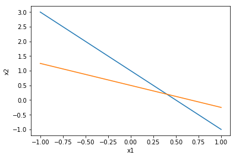

```python
# rozwiązanie graficzne układu 2 równań
# w każdym równaniu wyrażamy x_2 jako funkcję x_1 i wykreślamy te zależności
# Rozwiązaniem będzie punkt przecięcia prostych
# x_2=-2x_1+1
# x_2=-3/4x_1+1/2
%matplotlib  inline
import matplotlib.pyplot as plt
import numpy as np
x1 = np.linspace(-1, 1, 100)
plt.plot(x1,-2*x1+1)
plt.plot(x1,-3/4*x1+1/2)
plt.xlabel('x1')
plt.ylabel('x2')
plt.show()
```

Widzimy, że jest rozwiązanie ale trudno będzie odczytać z wykresu wartości $x_1$ i $x_2$.

Przedstawimy teraz metody pozwalające rozwiązać numerycznie układ równań.

### Macierzowa postać układu równań liniowych

Ogólnie, układ n równań liniowych możemy zapisać w postaci

\begin{equation} \begin{array}{cccc} a_{11}x_1 &+&a_{12}x_2&+&\ldots&+&a_{1n}x_1 &=& b_1\\ a_{21}x_1 &+&a_{22}x_2&+&\ldots&+&a_{2n}x_2 &=& b_2\\ \vdots & &\vdots& &\ddots& &\vdots &=& \vdots\\ a_{n1}x_1 &+&a_{n2}x_2&+&\ldots&+&a_{nn}x_n &=& b_n \end{array} \end{equation}

lub w postaci macierzowej

\begin{equation} \mathbb{Ax}=\mathbb{b} \end{equation}

gdzie

\begin{equation} \label{eq:ur1} \mathbb{A}=\left(\begin{matrix} a_{11}&a_{12} &\ldots&a_{1n}\\ a_{21}&a_{22}&\ldots&a_{2n}\\ \vdots &\vdots&\ddots&\vdots\\ a_{n1}&a_{n2}&\ldots&a_{nn} \end{matrix}\right), \mathbb{x}=\left(\begin{array}{c} x_1 \\ x_2\\ \vdots \\ x_n \end{array}\right), \mathbb{b}=\left(\begin{array}{c} b_1 \\ b_2\\ \vdots \\ b_n \end{array}\right) \end{equation}

Jednoznaczne rozwiązanie (\ref{eq:ur1}) istnieje gdy wyznacznik $\mathbb{A}$ jest różny od zera ($|\mathbb{A}|\neq 0$)

```python
# Obliczymy wyznacznik macierzy z (4) korzystając z modułu scipy

A=np.array([[2,1],[3,4]])
print(A)
from scipy import linalg
print ('\ndet(A)=',linalg.det(A))
```

```
[[2 1]
 [3 4]]

det(A)= 5.0
```

Gdy $|\mathbb{A}|= 0$ to mamy jedną z dwóch możliwości

\begin{enumerate} \item Układ równań zależnych z nieskończenie wieloma rozwiązaniami, np. \begin{equation} \begin{array}{cc} x_1 &+&2x_2 &=& 1\\ 2x_1&+&4x_2&=& 2\\ \end{array} \end{equation} Ponieważ drugie równanie to pierwsze pomnożone przez 2. Rozwiązanie: $x_1=1-2x_2$ dla dowolnego $x_2$ \item Sprzeczny układ równań - brak rozwiązań, np. \begin{equation} \begin{array}{cc} x_1 &+&2x_2 &=& 1\\ x_1&+&2x_2&=& 0\\ \end{array} \end{equation} \end{enumerate}

Gdy $|\mathbb{A}|\approx 0$ to macierz może być źle uwarunkowana, czyli rozwiązywanie układu równań z tą macierzą może prowadzić do dużych błędów.

Do zbadania jak uwarunkowana jest macierz $\mathbb{A}$ służy wskaźnik uwarunkowania

\begin{equation} k(\mathbb{A})=||\mathbb{A}||\cdot ||\mathbb{A^{-1}}|| \end{equation}

gdzie $||\mathbb{A}||$ oznacza normę macierzy $\mathbb{A} $

\begin{textboxa} Gdy $k(\mathbb{A})$ ma dużą wartość to macierz $\mathbb{A}$ jest źle uwarukowana \end{textboxa}

Normę macierzy można wprowadzić na wiele sposobów https://docs.scipy.org/doc/scipy/reference/tutorial/linalg.html. Tutaj podamy jedynie

\begin{equation} ||\mathbb{A}||_{\infty}=\max_{1\leq i \leq n}\sum_j{|a_{ij}|} \end{equation}

Teraz pokażemy sposób obliczenia normy dla przykładowej macierzy za pomocą linalg.norm() https://docs.scipy.org/doc/scipy/reference/generated/scipy.linalg.norm.html#scipy.linalg.norm

Obliczymy też wskaźnik uwarunkowania tej macierzy korzystając z linalg.cond() z numpy https://docs.scipy.org/doc/numpy/reference/generated/numpy.linalg.cond.html#numpy.linalg.cond

```python
A=np.array([[4,-3,2],[-1,0, 5],[2,6, -2]])
print(A)
print ('\nnorma(A)=',linalg.norm(A,np.inf))

from numpy import linalg as la
print ('k(A)=',la.cond(A,np.inf))
```

```
[[ 4 -3  2]
 [-1  0  5]
 [ 2  6 -2]]

norma(A)= 10.0
k(A)= 3.269230769230769
```

### Specjalne postaci macierzy układu równań

#### Macierz dolnotrójkątna

Macierz dolnotrójkątna ma niezerowe składowe na i poniżej przekątnej, np. ogólna postać takiej macierzy $(3\times 3)$

\begin{equation} \mathbb{L}=\left(\begin{matrix} l_{11} & 0 &0\\ l_{21} & l_{22} &0\\ l_{31} & l_{32} &l_{33} \end{matrix}\right) \end{equation}

Układ równań z macierzą $ \mathbb{L}$

\begin{equation} \mathbb{Lx}=\mathbb{b} \end{equation}

ma postać

\begin{equation} \begin{array}{ccc} l_{11}x_1 & & & & &=& b_1\\ l_{21}x_1 &+ & l_{22}x_2& & &=& b_2\\ l_{31}x_1 &+&l_{32}x_2&+&l_{33}x_3 &=& b_3 \end{array} \end{equation}

Rozwiązanie takiego układu otrzymamy łatwo metodą podstawienia w przód, tzn z pierwszego równania obliczamy $x_1$. Znając wartość $x_1$ obliczamy $x_2$ z drugiego równania. Analogicznie obliczamy pozostałe $x_i$.

\begin{equation} \begin{array}{ccc} x_1 &=& \frac{b_1}{l_{11}}\\ x_2 &=& \frac{b_2 -l_{21}x_1}{l_{22}}\\ x_3 &=& \frac{b_3-l_{31}x_1 -l_{32}x_2 }{l_{33}}\end{array} \end{equation}

#### Macierz górnotrójkątna

Macierz górnotrójkątna ma niezerowe składowe na i powyżej przekątnej, np. ogólna postać takiej macierzy $(3\times 3)$

\begin{equation} \mathbb{U}=\left(\begin{matrix} u_{11} &u_{12} &u_{13}\\ 0 & u_{22} &u_{23}\\ 0 & 0 &u_{33} \end{matrix}\right) \end{equation}

Układ równań z macierzą górnotrójkątną $$ \mathbb{Ux}=\mathbb{b} $$ rozwiązuje się metodą podstawiania wstecz, np.

\begin{equation} \begin{array}{ccc} u_{11}x_1 &+&u_{12}x_2&+&u_{13}x_3 &=& b_1\\ & &u_{22}x_2 &+ & u_{23}x_3 &=& b_2\\ & & & &u_{33}x_3 &=& b_3 \end{array} \end{equation}

Najpierw wyznaczmy $x_3$ i podstawiamy do pozostałych równań. Następnie obliczamy $x_2$ i w końcu $x_1$.

\begin{equation} \begin{array}{ccc} x_3 &=& \frac{b_3}{u_{33}}\\ x_2 &=& \frac{b_2 -u_{23}x_3}{u_{22}}\\ x_1 &=& \frac{b_3-u_{12}x_2 -u_{23}x_3 }{u_{11}} \end{array} \end{equation}

Macierze $\mathbb{L}$ i $\mathbb{U}$ są kluczowymi elementami metod bezpośredniego rozwiązywania układów równań liniowych.

Metoda eliminacji Gaussa sprowadza się do przekształcenia macierzy układu równań $\mathbb{A}$ w macierz górnotrójkątną $\mathbb{U}$.

Natomiast, w metodzie rozkładu LU macierz $\mathbb{A}$ przedstawia się w postaci $\mathbb{A}=\mathbb{LU}$ ponieważ układ równań $\mathbb{LUx}=\mathbb{b}$ również można rozwiązać metodą podstawiania, zastosowaną dwukrotnie. Najpierw obliczamy $\mathbb{y}$ z $\mathbb{Ly}=\mathbb{b}$, a następnie $\mathbb{x}$ z układu $\mathbb{Ux}=\mathbb{y}$

### Metoda eliminacji Gaussa

Przekształcanie układu równań poprzez zastąpienie równania liniową kombinacją innych równań nie zmienia jego rozwiązania.

Np., w układzie

\begin{equation} \begin{array}{cc} 2x_1 &+&x_2 &=& 1\\ x_1&+&3x_2&=& -2\\ \end{array} \end{equation}

zastąpimy rown.(2) taką kombinacją 2*rown.(2)-rown.(1) otrzymując

\begin{equation} \begin{array}{cc} 2x_1 &+&x_2 &=& 1\\ & &5x_2&=& -5\\ \end{array} \end{equation}

Łatwo sprawdzić, że obydwa układy mają to samo rozwiązanie ($x_1=1,x_2=-1$) ale drugi układ ma postać gotową do rozwiązania metodą podstawiania wstecz.

\begin{textboxa} Działanie eliminacji Gaussa \end{textboxa}

Metoda eliminacji Gaussa przebiega w dwóch etapach

\begin{enumerate} \item Przekształcenie układu równań $\mathbb{Ax}=\mathbb{b}$ do ukłądu $\mathbb{Ux}=\mathbb{b^{\prime}}$ z macierzą górnotrójkatną $\mathbb{U}$. \item Rozwiąznie układu równań $\mathbb{Ux}=\mathbb{b^{\prime}}$ metodą podstawiania wstecz. \end{enumerate}

Przykład

\begin{equation} \begin{array}{ccc} 8x_1 &-&6x_2 & + &2x_3 &=& 28\\ -4x_1 &+ & 11x_2&- &7x_3 &=& -40\\ 4x_1 &-&7x_2&+&6x_3 &=& 33 \end{array} \end{equation}

Eleminujemy pierwszy składnik w 2 i 3 równaniu za pomocą następującej przekształceń

Równ.(2)<-- Równ.(2) - (-4)/8 Równ.(1)

Równ.(3)<-- Równ.(3) - 4/8 Równ.(1)

Elementem głównym w tym kroku jest 8 - czynnik przy $x_1$ w równaniu 1, a mnożnikami są -4/8 i 4/8.

\begin{equation} \begin{array}{ccc} 8x_1 &-&6x_2 & + &2x_3 &=& 28\\ & & 8x_2&- &6x_3 &=& -26\\ & &-4x_2&+&5x_3 &=& 19 \end{array} \end{equation}

Teraz eleminimujemy wyraz z $x_2$ w równaniu 3 taką zamianą równania 3.

Równ.(3)<-- Równ.(3) - (-4)/8 Równ.(2)

Elementem głównym w drugim kroku jest 8 - czynnik przy $x_2$ w równaniu 2, a mnożnikiem jest -4/8.

\begin{equation} \begin{array}{ccc} 8x_1 &-&6x_2 & + &2x_3 &=& 28\\ & & 8x_2&- &6x_3 &=& -26\\ & & & &2x_3 &=& 6 \end{array} \end{equation}

Powyższe przekształcenia doprowadziły wyjściowy układ równań do układu typu $ \mathbb{Ux}=\mathbb{b}$

Teraz łatwo znajdziemy rozwiązanie metodą podstawiania wstecz

\begin{equation} \begin{split} &x_3=6/2=3\\ &x_2=(-26+6x_3)/8=(-26+18)/8=-1\\ &x_1=(28+6x_2-2x_3)/8=(28-6-6)/8=2 \end{split} \end{equation}

#### Przykład układu równań z fizyki

\begin{figure} \includegraphics[width=6cm]{obwod2E.jpg} \caption{\label{fig:obw} Obwód elektryczny z dwoma oczkami.} \end{figure}

Z praw Kirchoffa otrzymamy równania na prądy $i_1$, $i_2$ i $i_3$.

Prądy w węźle

$$i_1-i_2-i_3=0$$

Lewe oczko

$$-i_1 R_1-i_2 R_2+V_1=0$$

Prawe oczko

$$ i_2 R_2-i_3 R_3 -V_2=0$$

Zapiszemy ten układ równań w postaci macierzowej

\begin{equation} \label{eq:ur_oe} \left( \begin{array}{ccc} 1 & -1& -1\\ R_1 & R_2 & 0\\ 0& R_2 & -R_3\end{array} \right) \left(\begin{array}{c} i_1 \\ i_2 \\i_3 \end{array}\right) = \left(\begin{array}{c} 0 \\ V_1\\V_2 \end{array}\right) \end{equation}

Wykorzystamy metodę scipy.linalg.solve() https://docs.scipy.org/doc/scipy/reference/generated/scipy.linalg.solve.html#scipy.linalg.solve do rozwiązania układu (\ref{eq:ur_oe}) dla następujących danych

$R_1=R_3=2 k\Omega$, $R_2=1 k\Omega$, $V_1=5 V$, $V_2=2 V$.

```python
R1=2000
R3=R1
R2=1000
V1=5
V2=2
A=np.array([[1,-1,-1],[R1,R2, 0],[0,R2, -R3]])
v=np.array([0, V1, V2])
i=linalg.solve(A,v)

print('wyniki w mA,   i=',i*1000)
```

```
wyniki w mA,   i= [ 1.625  1.75  -0.125]
```

```python
# Drugi przykład wykorzystania metody solve do rozwiązania układu (22)
A=np.array([[8,-6,2],[-4,11, -7],[4,-7, 6]])
b=np.array([28,-40, 33])
x=linalg.solve(A,b)
print('x=',x)
```

```
x= [ 2. -1.  3.]
```